# Risk Factor Analysis

## Outcome Variable

**Outcome Variable:** whz

## Predictor Variables

**Intervention Variable:** brthmon

**Adjustment Set:**

unadjusted

## Stratifying Variables

The analysis was stratified on these variable(s):

- studyid
- country

## Data Summary

| studyid | country | brthmon | n_cell | n | outcome_variable |
| --- | --- | --- | --- | --- | --- |
| CMC-V-BCS-2002 | India | 1 | 10 | 89 | whz |
| CMC-V-BCS-2002 | India | 2 | 1 | 89 | whz |
| CMC-V-BCS-2002 | India | 3 | 7 | 89 | whz |
| CMC-V-BCS-2002 | India | 4 | 9 | 89 | whz |
| CMC-V-BCS-2002 | India | 5 | 10 | 89 | whz |
| CMC-V-BCS-2002 | India | 6 | 9 | 89 | whz |
| CMC-V-BCS-2002 | India | 7 | 7 | 89 | whz |
| CMC-V-BCS-2002 | India | 8 | 4 | 89 | whz |
| CMC-V-BCS-2002 | India | 9 | 10 | 89 | whz |
| CMC-V-BCS-2002 | India | 10 | 8 | 89 | whz |
| CMC-V-BCS-2002 | India | 11 | 11 | 89 | whz |
| CMC-V-BCS-2002 | India | 12 | 3 | 89 | whz |
| CMIN | Bangladesh | 1 | 2 | 19 | whz |
| CMIN | Bangladesh | 2 | 4 | 19 | whz |
| CMIN | Bangladesh | 3 | 0 | 19 | whz |
| CMIN | Bangladesh | 4 | 2 | 19 | whz |
| CMIN | Bangladesh | 5 | 1 | 19 | whz |
| CMIN | Bangladesh | 6 | 0 | 19 | whz |
| CMIN | Bangladesh | 7 | 4 | 19 | whz |
| CMIN | Bangladesh | 8 | 2 | 19 | whz |
| CMIN | Bangladesh | 9 | 1 | 19 | whz |
| CMIN | Bangladesh | 10 | 1 | 19 | whz |
| CMIN | Bangladesh | 11 | 2 | 19 | whz |
| CMIN | Bangladesh | 12 | 0 | 19 | whz |
| EE | Pakistan | 1 | 40 | 178 | whz |
| EE | Pakistan | 2 | 36 | 178 | whz |
| EE | Pakistan | 3 | 16 | 178 | whz |
| EE | Pakistan | 4 | 7 | 178 | whz |
| EE | Pakistan | 5 | 0 | 178 | whz |
| EE | Pakistan | 6 | 0 | 178 | whz |

[output cut: 90 more lines]

The following strata were considered:

- studyid: CMC-V-BCS-2002, country: India
- studyid: CMIN, country: Bangladesh
- studyid: EE, country: Pakistan
- studyid: GMS-Nepal, country: Nepal
- studyid: IRC, country: India
- studyid: MAL-ED, country: Bangladesh
- studyid: MAL-ED, country: India
- studyid: MAL-ED, country: Nepal
- studyid: PROVIDE, country: Bangladesh
- studyid: ResPak, country: Pakistan

### Dropped Strata

Some strata were dropped due to rare outcomes:

- studyid: CMC-V-BCS-2002, country: India
- studyid: CMIN, country: Bangladesh
- studyid: EE, country: Pakistan
- studyid: GMS-Nepal, country: Nepal
- studyid: MAL-ED, country: India
- studyid: MAL-ED, country: Nepal
- studyid: ResPak, country: Pakistan

## Methods Detail

We’re interested in the causal parameters $E[Y_a]$ for all values of $a \in \mathcal{A}$. These parameters represent the mean outcome if, possibly contrary to fact, we intervened to set all units to have $A=a$. Under the randomization and positivity assumptions, these are identified by the statistical parameters $\psi_a=E_W[E_{Y|A,W}(Y|A=a,W)]$. In addition, we’re interested in the mean of $Y$, $E[Y]$ under no intervention (the observed mean). We will estimate these parameters by using SuperLearner to fit the relevant likelihood factors – $E_{Y|A,W}(Y|A=a,W)$ and $p(A=a|W)$, and then updating our likelihood fit using a joint TMLE.

For unadjusted analyses ($W=\{\}$), initial likelihoods were estimated using Lrnr_glm to estimate the simple $E(Y|A)$ and Lrnr_mean to estimate $p(A)$. For adjusted analyses, a small library containing Lrnr_glmnet, Lrnr_xgboost, and Lrnr_mean was used.

Having estimated these parameters, we will then use the delta method to estimate relative risks and attributable risks relative to a prespecified baseline level of $A$.

# Results Detail

## Results Plots

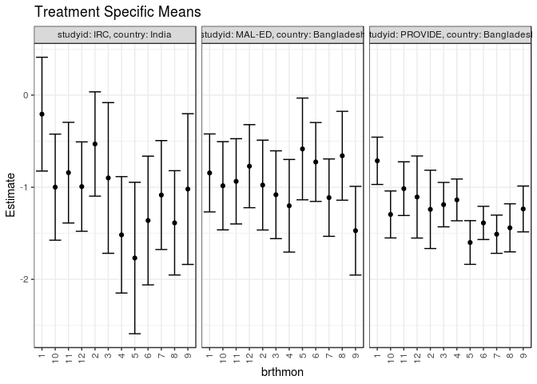

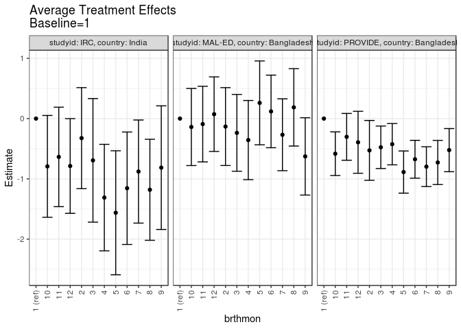

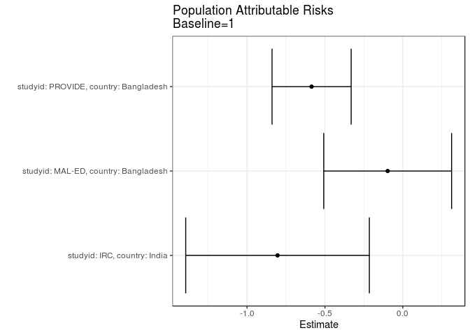

## Results Table

### Parameter: TSM

| studyid | country | intervention_level | baseline_level | estimate | ci_lower | ci_upper |
| --- | --- | --- | --- | --- | --- | --- |
| IRC | India | 1 | NA | -0.2064516 | -0.8241587 | 0.4112554 |
| IRC | India | 2 | NA | -0.5304348 | -1.0966348 | 0.0357652 |
| IRC | India | 3 | NA | -0.8991667 | -1.7172346 | -0.0810988 |
| IRC | India | 4 | NA | -1.5168421 | -2.1488141 | -0.8848701 |
| IRC | India | 5 | NA | -1.7686667 | -2.5910096 | -0.9463238 |
| IRC | India | 6 | NA | -1.3615385 | -2.0604069 | -0.6626700 |
| IRC | India | 7 | NA | -1.0848387 | -1.6762039 | -0.4934735 |
| IRC | India | 8 | NA | -1.3869444 | -1.9532683 | -0.8206205 |
| IRC | India | 9 | NA | -1.0200000 | -1.8383304 | -0.2016696 |
| IRC | India | 10 | NA | -0.9990909 | -1.5750645 | -0.4231173 |
| IRC | India | 11 | NA | -0.8418421 | -1.3887010 | -0.2949832 |
| IRC | India | 12 | NA | -0.9930233 | -1.4781855 | -0.5078611 |
| MAL-ED | Bangladesh | 1 | NA | -0.8447368 | -1.2679122 | -0.4215615 |
| MAL-ED | Bangladesh | 2 | NA | -0.9766667 | -1.4645399 | -0.4887935 |
| MAL-ED | Bangladesh | 3 | NA | -1.0814286 | -1.5581991 | -0.6046581 |
| MAL-ED | Bangladesh | 4 | NA | -1.2013158 | -1.7040536 | -0.6985780 |
| MAL-ED | Bangladesh | 5 | NA | -0.5841176 | -1.1364997 | -0.0317356 |
| MAL-ED | Bangladesh | 6 | NA | -0.7257143 | -1.1540291 | -0.2973994 |
| MAL-ED | Bangladesh | 7 | NA | -1.1130769 | -1.5329650 | -0.6931889 |
| MAL-ED | Bangladesh | 8 | NA | -0.6582609 | -1.1407755 | -0.1757462 |
| MAL-ED | Bangladesh | 9 | NA | -1.4718750 | -1.9537166 | -0.9900334 |
| MAL-ED | Bangladesh | 10 | NA | -0.9840000 | -1.4629655 | -0.5050345 |
| MAL-ED | Bangladesh | 11 | NA | -0.9360000 | -1.3986933 | -0.4733067 |
| MAL-ED | Bangladesh | 12 | NA | -0.7714583 | -1.2225093 | -0.3204073 |
| PROVIDE | Bangladesh | 1 | NA | -0.7130000 | -0.9699481 | -0.4560519 |
| PROVIDE | Bangladesh | 2 | NA | -1.2404167 | -1.6655483 | -0.8152851 |
| PROVIDE | Bangladesh | 3 | NA | -1.1888889 | -1.4299534 | -0.9478243 |
| PROVIDE | Bangladesh | 4 | NA | -1.1375000 | -1.3642553 | -0.9107447 |
| PROVIDE | Bangladesh | 5 | NA | -1.6000000 | -1.8372875 | -1.3627125 |
| PROVIDE | Bangladesh | 6 | NA | -1.3874667 | -1.5677779 | -1.2071555 |
| PROVIDE | Bangladesh | 7 | NA | -1.5102667 | -1.7175159 | -1.3030175 |
| PROVIDE | Bangladesh | 8 | NA | -1.4407547 | -1.7015896 | -1.1799199 |
| PROVIDE | Bangladesh | 9 | NA | -1.2358182 | -1.4847475 | -0.9868889 |
| PROVIDE | Bangladesh | 10 | NA | -1.2955556 | -1.5507933 | -1.0403178 |
| PROVIDE | Bangladesh | 11 | NA | -1.0155556 | -1.3070053 | -0.7241058 |
| PROVIDE | Bangladesh | 12 | NA | -1.1061905 | -1.5519148 | -0.6604661 |

### Parameter: E(Y)

| studyid | country | intervention_level | baseline_level | estimate | ci_lower | ci_upper |
| --- | --- | --- | --- | --- | --- | --- |
| IRC | India | NA | NA | -1.0105831 | -1.197302 | -0.8238643 |
| MAL-ED | Bangladesh | NA | NA | -0.9418605 | -1.086983 | -0.7967375 |
| PROVIDE | Bangladesh | NA | NA | -1.2984586 | -1.375276 | -1.2216415 |

### Parameter: ATE

| studyid | country | intervention_level | baseline_level | estimate | ci_lower | ci_upper |
| --- | --- | --- | --- | --- | --- | --- |
| IRC | India | 1 | 1 | 0.0000000 | 0.0000000 | 0.0000000 |
| IRC | India | 2 | 1 | -0.3239832 | -1.1619238 | 0.5139574 |
| IRC | India | 3 | 1 | -0.6927151 | -1.7177990 | 0.3323689 |
| IRC | India | 4 | 1 | -1.3103905 | -2.1941046 | -0.4266764 |
| IRC | India | 5 | 1 | -1.5622151 | -2.5907139 | -0.5337162 |
| IRC | India | 6 | 1 | -1.1550868 | -2.0878136 | -0.2223601 |
| IRC | India | 7 | 1 | -0.8783871 | -1.7335332 | -0.0232410 |
| IRC | India | 8 | 1 | -1.1804928 | -2.0185171 | -0.3424685 |
| IRC | India | 9 | 1 | -0.8135484 | -1.8388418 | 0.2117450 |
| IRC | India | 10 | 1 | -0.7926393 | -1.6372147 | 0.0519361 |
| IRC | India | 11 | 1 | -0.6353905 | -1.4603854 | 0.1896045 |
| IRC | India | 12 | 1 | -0.7865716 | -1.5720297 | -0.0011136 |
| MAL-ED | Bangladesh | 1 | 1 | 0.0000000 | 0.0000000 | 0.0000000 |
| MAL-ED | Bangladesh | 2 | 1 | -0.1319298 | -0.7777608 | 0.5139012 |
| MAL-ED | Bangladesh | 3 | 1 | -0.2366917 | -0.8741770 | 0.4007936 |
| MAL-ED | Bangladesh | 4 | 1 | -0.3565789 | -1.0137111 | 0.3005532 |
| MAL-ED | Bangladesh | 5 | 1 | 0.2606192 | -0.4352280 | 0.9564664 |
| MAL-ED | Bangladesh | 6 | 1 | 0.1190226 | -0.4830829 | 0.7211280 |
| MAL-ED | Bangladesh | 7 | 1 | -0.2683401 | -0.8644805 | 0.3278003 |
| MAL-ED | Bangladesh | 8 | 1 | 0.1864760 | -0.4553167 | 0.8282686 |
| MAL-ED | Bangladesh | 9 | 1 | -0.6271382 | -1.2684249 | 0.0141486 |
| MAL-ED | Bangladesh | 10 | 1 | -0.1392632 | -0.7783917 | 0.4998654 |
| MAL-ED | Bangladesh | 11 | 1 | -0.0912632 | -0.7182898 | 0.5357635 |
| MAL-ED | Bangladesh | 12 | 1 | 0.0732785 | -0.5452070 | 0.6917641 |
| PROVIDE | Bangladesh | 1 | 1 | 0.0000000 | 0.0000000 | 0.0000000 |
| PROVIDE | Bangladesh | 2 | 1 | -0.5274167 | -1.0241653 | -0.0306680 |
| PROVIDE | Bangladesh | 3 | 1 | -0.4758889 | -0.8282161 | -0.1235617 |
| PROVIDE | Bangladesh | 4 | 1 | -0.4245000 | -0.7671956 | -0.0818044 |
| PROVIDE | Bangladesh | 5 | 1 | -0.8870000 | -1.2367537 | -0.5372463 |
| PROVIDE | Bangladesh | 6 | 1 | -0.6744667 | -0.9883686 | -0.3605647 |
| PROVIDE | Bangladesh | 7 | 1 | -0.7972667 | -1.1273796 | -0.4671537 |
| PROVIDE | Bangladesh | 8 | 1 | -0.7277547 | -1.0938929 | -0.3616166 |
| PROVIDE | Bangladesh | 9 | 1 | -0.5228182 | -0.8805724 | -0.1650639 |
| PROVIDE | Bangladesh | 10 | 1 | -0.5825556 | -0.9447276 | -0.2203835 |
| PROVIDE | Bangladesh | 11 | 1 | -0.3025556 | -0.6910981 | 0.0859870 |
| PROVIDE | Bangladesh | 12 | 1 | -0.3931905 | -0.9076732 | 0.1212923 |

### Parameter: PAR

| studyid | country | intervention_level | baseline_level | estimate | ci_lower | ci_upper |
| --- | --- | --- | --- | --- | --- | --- |
| IRC | India | 1 | NA | -0.8041315 | -1.3935851 | -0.2146779 |
| MAL-ED | Bangladesh | 1 | NA | -0.0971236 | -0.5075955 | 0.3133483 |
| PROVIDE | Bangladesh | 1 | NA | -0.5854586 | -0.8393820 | -0.3315353 |